# exercise5

第一题：

1. 使用numpy.random.randn分别创建10*10，100*100和1000*1000的数据，并分别计算他们的均值和标准差。

```python
import numpy as np
tensize=np.random.randn(10,10)
print("10*10数组的均值为："+str(tensize.mean())+"，标准差为："+str(tensize.std())+"\n")
hundredsize=np.random.randn(100,100)
print("100*100数组的均值为："+str(hundredsize.mean())+"，标准差为："+str(hundredsize.std())+"\n")
thousandsize=np.random.randn(1000,1000)
print("1000*1000数组的均值为："+str(thousandsize.mean())+"，标准差为："+str(thousandsize.std())+"\n")
```

```
10*10数组的均值为：-0.005873203817273031，标准差为：1.0952021467820496

100*100数组的均值为：0.022014190566681642，标准差为：0.9963021153037178

1000*1000数组的均值为：-6.335669537086761e-05，标准差为：1.0008974751147637
```

第二题：

2. 给定一个一维数组，定义函数moving_average(a,n)计算此数组的滑动平均值，a为数组，n为窗口长度。给出例子并作图显示。

```python
def moving_average(a,n):
    movea=[]
    for i in range(len(a)-n+1):
        movea.append(a[i:i+n+1].mean())
    return movea
```

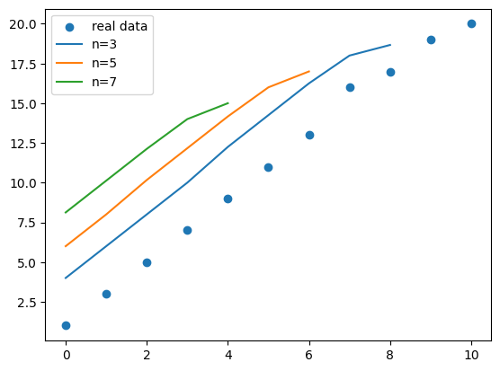

```python
import matplotlib.pyplot as plt
exam=np.array([1,3,5,7,9,11,13,16,17,19,20])
x=np.arange(len(exam))
plt.scatter(x,exam)
plt.plot(moving_average(exam,3))
plt.plot(moving_average(exam,5))
plt.plot(moving_average(exam,7))
plt.legend(["real data","n=3","n=5","n=7"],loc='upper left')
```

第三题：

3. 对于一个任意二维数组，给定此数组中某个元素的位置(i,j)和一个长度值l,从此二维数组中提取出以此元素为中心，维数为(2*l+1,2*l+1)的方阵。如果越界，则使用0补齐。

```python
def center(a,pos,l):
    newarray=np.zeros((2*l+1,2*l+1))
    xs=max(0,pos[0]-l)
    xe=min(pos[0]+l+1,a.shape[0])
    ys=max(0,pos[1]-l)
    ye=min(pos[1]+l+1,a.shape[1])
    acut=a[xs:xe][:,ys:ye]
    newarray[xs+(l-pos[0]):xe+(l-pos[0])][:,ys+(l-pos[1]):ye+(l-pos[1])]=acut #使pos对齐newarray的中心点(l,l)
    return newarray
```

```python
a=np.array([[1,2,3,4],[5,6,7,8],[9,10,11,12]])
print(center(a,(1,3),2))
print(center(a,(1,2),1))
print(center(a,(1,0),2))
print(center(a,(1,1),2))
print(center(a.T,(3,1),2))
```

```
[[ 0.  0.  0.  0.  0.]
 [ 2.  3.  4.  0.  0.]
 [ 6.  7.  8.  0.  0.]
 [10. 11. 12.  0.  0.]
 [ 0.  0.  0.  0.  0.]]
[[ 2.  3.  4.]
 [ 6.  7.  8.]
 [10. 11. 12.]]
[[ 0.  0.  0.  0.  0.]
 [ 0.  0.  1.  2.  3.]
 [ 0.  0.  5.  6.  7.]
 [ 0.  0.  9. 10. 11.]
 [ 0.  0.  0.  0.  0.]]
[[ 0.  0.  0.  0.  0.]
 [ 0.  1.  2.  3.  4.]
 [ 0.  5.  6.  7.  8.]
 [ 0.  9. 10. 11. 12.]
 [ 0.  0.  0.  0.  0.]]
[[ 0.  2.  6. 10.  0.]
 [ 0.  3.  7. 11.  0.]
 [ 0.  4.  8. 12.  0.]
 [ 0.  0.  0.  0.  0.]
 [ 0.  0.  0.  0.  0.]]
```

第四题：

4. 幻方(Magic Square)是指每行、列和两个对角线上的数字和都相等的方阵。

例如：A=np.array([[17, 24, 1, 8, 15],

[23, 5, 7, 14, 16],

[ 4, 6, 13, 20, 22],

[10, 12, 19, 21, 3],

[11, 18, 25, 2, 9]])

```python
def lalouberemagic(n):
    magic=np.zeros((n,n))
    row=0
    col=2
    magic[row][col]=1
    for i in range(n*n-1):
        o_row=row
        o_col=col
        row-=1
        col+=1
        if row<0:
            row=n-1
        if col>=n:
            col=0
        if magic[row][col]!=0:
            row=o_row+1
            col=o_col
        magic[row][col]=i+2
    return magic
def display_magic(m):
    print("这是"+str(len(m))+"阶（奇数阶）幻方")
    print(m)
    print("各行、列和为：")
    print(m.sum(0),m.sum(1))
```

```python
display_magic(lalouberemagic(5))
display_magic(lalouberemagic(7))
display_magic(lalouberemagic(9))
```

```
这是5阶（奇数阶）幻方
[[17. 24.  1.  8. 15.]
 [23.  5.  7. 14. 16.]
 [ 4.  6. 13. 20. 22.]
 [10. 12. 19. 21.  3.]
 [11. 18. 25.  2.  9.]]
各行、列和为：
[65. 65. 65. 65. 65.] [65. 65. 65. 65. 65.]
这是7阶（奇数阶）幻方
[[39. 48.  1. 10. 19. 28. 30.]
 [47.  7.  9. 18. 27. 29. 38.]
 [ 6.  8. 17. 26. 35. 37. 46.]
 [14. 16. 25. 34. 36. 45.  5.]
 [15. 24. 33. 42. 44.  4. 13.]
 [23. 32. 41. 43.  3. 12. 21.]
 [31. 40. 49.  2. 11. 20. 22.]]
各行、列和为：
[175. 175. 175. 175. 175. 175. 175.] [175. 175. 175. 175. 175. 175. 175.]
这是9阶（奇数阶）幻方
[[69. 80.  1. 12. 23. 34. 45. 47. 58.]
 [79.  9. 11. 22. 33. 44. 46. 57. 68.]
 [ 8. 10. 21. 32. 43. 54. 56. 67. 78.]
 [18. 20. 31. 42. 53. 55. 66. 77.  7.]
 [19. 30. 41. 52. 63. 65. 76.  6. 17.]
 [29. 40. 51. 62. 64. 75.  5. 16. 27.]
 [39. 50. 61. 72. 74.  4. 15. 26. 28.]
 [49. 60. 71. 73.  3. 14. 25. 36. 38.]
 [59. 70. 81.  2. 13. 24. 35. 37. 48.]]
各行、列和为：
[369. 369. 369. 369. 369. 369. 369. 369. 369.] [369. 369. 369. 369. 369. 369. 369. 369. 369.]
```

第五题：

5. 设二次函数 p(x)=ax^2+bx+c过点(x_i,y_i) for i=1, 2, 3. 求a，b，c的值。

例如过这三个点(-1,1),(0,-1),(2,7)，则可以得到一个线性方程组，使用numpy.linalg中solve函数解方程即可。

```python
def solveabc(*points):
    if len(points)!=3:
        return "Please input 3 points!"
    xlist=[]
    ylist=[]
    for point in points:
        xlist.append(point[0])
        ylist.append(point[1])
    X=np.array([[x**2,x,1] for x in xlist])
    Y=np.array(ylist)
    return np.linalg.solve(X,Y)
```

```python
print(solveabc((-1,1),(0,-1),(2,7)))
print(solveabc((-1,0),(0,1),(1,0)))
```

```
[ 2. -0. -1.]
[-1.  0.  1.]
```